# 1. Data understanding

### 4.3 Generate a boxplot of Fwd Packet Length Mean grouped by Label. Analyse the differences across categories.

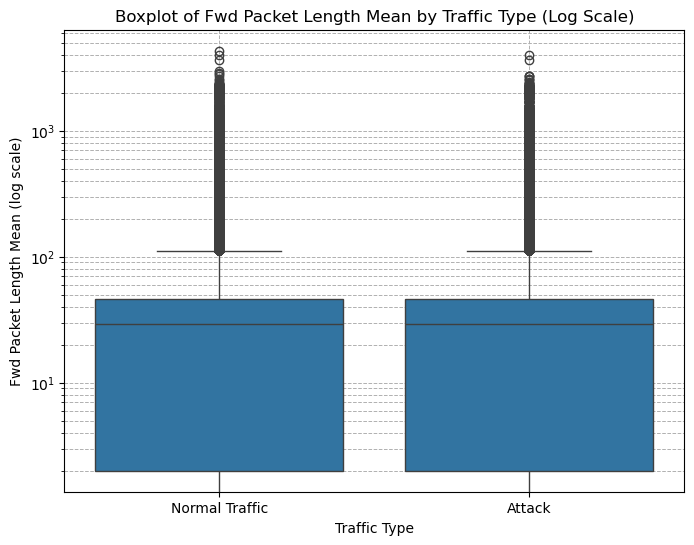

```python
# Set figure size
plt.figure(figsize=(8, 6))

# Create boxplot with Label on x-axis and Fwd Packet Length Mean on y-axis
sns.boxplot(x='Label', y='Fwd Packet Length Mean', data=new_df)

# Set plot title
plt.title('Boxplot of Fwd Packet Length Mean by Traffic Type (Log Scale)')

# Label x and y axes
plt.xlabel('Traffic Type')
plt.ylabel('Fwd Packet Length Mean (log scale)')

# Apply log scale to y-axis to handle wide range of values
plt.yscale('log')

# Add grid lines for both major and minor ticks for better readability
plt.grid(True, which="both", ls="--", linewidth=0.7)

# Display the plot
plt.show()
```

### 4.4 Hypothesis test: Is there a significant difference in mean Flow Duration between Normal Traffic and Attack classes? State H0 ; H1, choose an appropriate test, perform it, and interpret the results.

```python
# Hypothesis Testing - Mean Flow Duration: Normal Traffic vs Attack
# H0: Mean Flow Duration is EQUAL for both classes
# H1: Mean Flow Duration is DIFFERENT between classes

normal_duration = new_df[new_df['Label'] == 'Normal Traffic']['Flow Duration']
attack_duration  = new_df[new_df['Label'] == 'Attack']['Flow Duration']

t_stat, p_value = stats.ttest_ind(normal_duration, attack_duration, equal_var=False)
alpha = 0.05

print('Hypothesis Test: Mean Flow Duration - Normal Traffic vs Attack')
print('=' * 65)
print(f"  H0 (Null)       : Mean Flow Duration is EQUAL for both classes.")
print(f"  H1 (Alternative): Mean Flow Duration is DIFFERENT between classes.")
print(f"  Test chosen     : Independent samples t-test (Welch's t-test)")
print(f"  Significance    : alpha = {alpha}\n")
print(f"  Normal Traffic - Mean: {normal_duration.mean():.4f}, n={len(normal_duration):,}")
print(f"  Attack         - Mean: {attack_duration.mean():.4f}, n={len(attack_duration):,}\n")
print(f"  T-statistic : {t_stat:.4f}")
print(f"  P-value     : {p_value:.6f}\n")

if p_value < alpha:
    print(f"  Result: p-value ({p_value:.6f}) < alpha ({alpha})")
    print("  Decision: REJECT the null hypothesis (H0).")
    print("  Interpretation: There IS a statistically significant difference in mean Flow Duration.")
else:
    print(f"  Result: p-value ({p_value:.6f}) >= alpha ({alpha})")
    print("  Decision: FAIL to reject the null hypothesis (H0).")
    print("  Interpretation: No statistically significant difference was found.")
```

```
Hypothesis Test: Mean Flow Duration - Normal Traffic vs Attack
=================================================================
  H0 (Null)       : Mean Flow Duration is EQUAL for both classes.
  H1 (Alternative): Mean Flow Duration is DIFFERENT between classes.
  Test chosen     : Independent samples t-test (Welch's t-test)
  Significance    : alpha = 0.05

  Normal Traffic - Mean: 8966348.4847, n=288,548
  Attack         - Mean: 8909046.4443, n=199,531

  T-statistic : 0.7166
  P-value     : 0.473601

  Result: p-value (0.473601) >= alpha (0.05)
  Decision: FAIL to reject the null hypothesis (H0).
  Interpretation: No statistically significant difference was found.
```

Ushudha Sanwa Limbu

Network Traffic Data Analysis · IDS Project

ushudhasanwa@gmail.com [GitHub](https://github.com/ushudhaa) [LinkedIn](https://www.linkedin.com/in/ushudha-sanwa-limbu-8ba84826a/)